# 蛙与蟾名录：七成的抽屉是空的

TidyTuesday · 2026-10-13 (Week 41) · AmphibiaWeb 蛙与蟾条目 8,018 行

作者

zlZayn

发布于

2026年10月28日

# 七成的抽屉是空的

70.5% 的条目没有一句正文 · 0 行有 IUCN 状态 · 10.2× 科与科之间的覆盖率差

8,018 行、26 列、57 个科、504 个属——看上去像一部蛙类百科，实际上是一册**名录加 29.5% 的物种志**。

其中 5,650 行（70.5%）除了名字、科、属和分布码之外什么都没有，连作者和日期都没有。剩下 2,368 行写过正文。

这 2,368 行不是随机分布的：**一个科被写了几分，取决于当年刚好是谁在写这个科**。

这条主线决定了本页的读法：所有「差异」都是**记录口径的差异**，不是蛙类本身的差异。IUCN 那一列 8,018 行全空，官方问题清单里的第三条在本快照里无法回答；`distribution` 是散文式的范围描述而不是产地坐标，所以本页也没有地图。

## 一、先把口径钉死：这是 8,018 个物种，不是一个物种的 8,018 次观察

raw 8018 -> plotted 8018 (全表入图，无剔除)

**粒度**：8,018 行 = 8,018 个物种（`amphib_id` 全表唯一），全部是 `ordr == "Anura"`，落在 57 个科、504 个属里。**不是**观察记录，也不是产地坐标——一行就是一个物种条目，量的是「这个物种在档案里被写了多少」，不是「这个物种有多少」。

一个侧面的口径证据：`amphib_id` 的取值跨度是 10,215，而实际只有 8,018 行，缺口 2,197。原始 XML dump 在入库前被过滤成只有无尾目，缺口里既有别的目也有已撤记录；**因此不能拿 id 缺口推算物种总数**。

表 1: 口径表：26 个字段各自填了多少（按非空占比降序）。这张表是后面所有图的前提——空白不是 0，是「没记录」

| 字段 | 类型 | 非空行数 | 非空占比 |
| --- | --- | --- | --- |
| amphib_id | num | 8,018 | 100.0% |
| family | chr | 8,018 | 100.0% |
| genus | chr | 8,018 | 100.0% |
| ordr | chr | 8,018 | 100.0% |
| specificepithet | chr | 8,018 | 100.0% |
| isocc | chr | 7,987 | 99.6% |
| subfamily | chr | 4,648 | 58.0% |
| common_name | chr | 2,774 | 34.6% |
| edit_date | date | 2,359 | 29.4% |
| editedby | chr | 2,344 | 29.2% |
| distribution | chr | 2,252 | 28.1% |
| refs | chr | 2,076 | 25.9% |
| life_history | chr | 2,053 | 25.6% |
| description | chr | 2,011 | 25.1% |
| submit_date | date | 1,901 | 23.7% |
| submittedby | chr | 1,885 | 23.5% |
| comments | chr | 1,785 | 22.3% |
| trends_and_threats | chr | 1,524 | 19.0% |
| clade | chr | 808 | 10.1% |
| larva | chr | 615 | 7.7% |
| relation_to_humans | chr | 308 | 3.8% |
| national_status | chr | 209 | 2.6% |
| regional_status | chr | 176 | 2.2% |
| lannoo | chr | 96 | 1.2% |
| intro_isocc | chr | 66 | 0.8% |
| interntnl_status | chr | 0 | 0.0% |

**三类字段，三种读法。**

- **标识与分类**（`amphib_id` / `ordr` / `family` / `genus` / `specificepithet` / `isocc`）：100% 或 99.6% 有值，是名录的骨架。
- **散文**（`description` / `distribution` / `life_history` / `larva` / `trends_and_threats` / `comments`）：29.5% 的条目至少有一块，最多的是 `distribution`（2,252 行）。
- **评估与署名**（`interntnl_status` / `national_status` / `regional_status` / `submittedby` / `edit_date`）：几乎为空。

最后一类里 `interntnl_status` 是 0 行有值。官方问题清单里「IUCN 状态如何在科或地区间变化」这一条，本快照没有可用数据；本页不会用别的列去凑一个替代品。

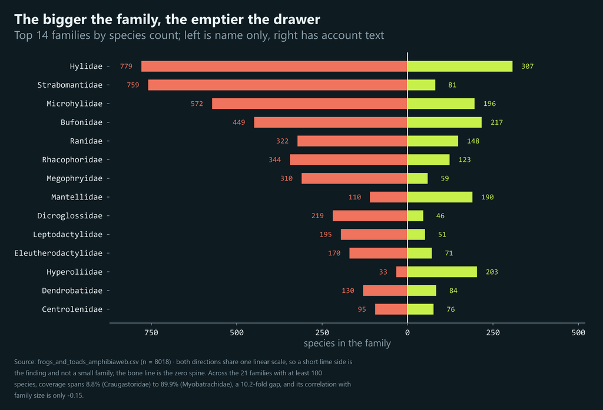

图 1: Coverage across frog families runs from 9 to 90 percent, and the largest families are among the emptiest.

**读数**：入图的 14 个科占了全表 6,339 行（79.1%）。左手珊瑚条是**只有名字**的条目，右手青柠条是至少写过一块正文的条目，两侧共用一根线性轴——所以青柠条短是真的写得少，不是科小。

两极不在这 14 个科里。把 `n >= 100` 的 21 个科一起看，两端是 Myobatrachidae 和 Craugastoridae（两者排在第 15、16 位，所以不在图 1 上）。

Myobatrachidae 有 138 个物种，写到 90%；Craugastoridae 有 136 个物种，只有 9%。**两端差 10.2 倍**。

而写得最少的那一档坐着最大的两个科：Hylidae（1,086 个物种）只有 28% 有正文，Strabomantidae（840 个物种）只有 10%。

在 `n >= 100` 的 21 个科里，科的大小与覆盖率的相关只有 -0.15——**规模不买正文**。

这张图能说的：科与科之间的覆盖率差异到了十倍量级。这张图不能说的：不能反推「哪个科被研究得少」——覆盖率是**这个档案写了什么**，不是**这个类群被研究了多少**。

表 2: 图 1 的原始数字（覆盖率 = 有正文 ÷ 物种数；与图上同一份聚合）

| 科 | 属数 | 物种数 | 有正文 | 只有名字 | 覆盖率 |
| --- | --- | --- | --- | --- | --- |
| Hylidae | 85 | 1086 | 307 | 779 | 28.3% |
| Strabomantidae | 20 | 840 | 81 | 759 | 9.6% |
| Microhylidae | 59 | 768 | 196 | 572 | 25.5% |
| Bufonidae | 55 | 666 | 217 | 449 | 32.6% |
| Ranidae | 25 | 470 | 148 | 322 | 31.5% |
| Rhacophoridae | 22 | 467 | 123 | 344 | 26.3% |
| Megophryidae | 14 | 369 | 59 | 310 | 16.0% |
| Mantellidae | 12 | 300 | 190 | 110 | 63.3% |
| Dicroglossidae | 15 | 265 | 46 | 219 | 17.4% |
| Leptodactylidae | 13 | 246 | 51 | 195 | 20.7% |
| Eleutherodactylidae | 4 | 241 | 71 | 170 | 29.5% |
| Hyperoliidae | 17 | 236 | 203 | 33 | 86.0% |
| Dendrobatidae | 16 | 214 | 84 | 130 | 39.3% |
| Centrolenidae | 12 | 171 | 76 | 95 | 44.4% |

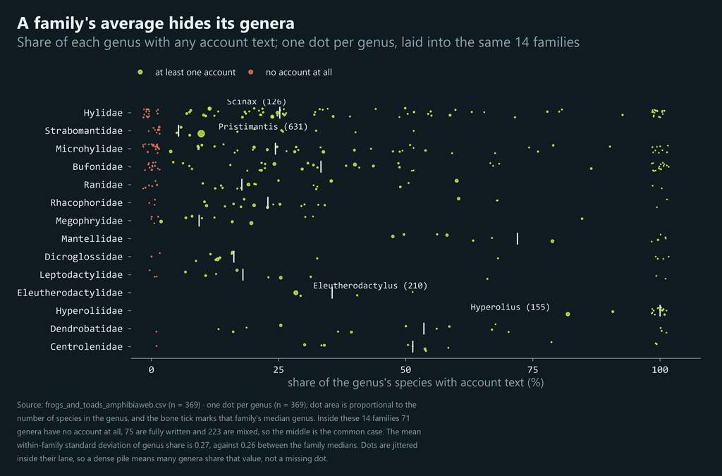

图 2: Inside a single family some genera are fully written and others are blank, so a family average describes almost none of its genera.

**读数**：入图的 369 个属里，71 个一个条目都没写过（全表 92 个），75 个写得一个不剩（全表 119 个），其余 223 个是半写不写。所以这里**不是**清晰的两层结构——中间地带才是多数。

真正值得注意的是离散程度：**科内的属级离散和科间一样大**。属级覆盖率的科内标准差平均 0.27，而科中位数之间的标准差只有 0.26。

平均每个科内部，最高与最低的属差 81 个百分点。Hyperoliidae 的中位属写到 100%，它内部完全空白的属是 0 个（共 17 个属）；Strabomantidae 的中位属只有 5%，它的 20 个属里也有 11 个写过。

结论因此要说得比「科」精确：**同一科里的属可以完全不在一个状态上，所以拿科平均值去描述这批记录会抹掉真实的差异**。四个最大的属（Pristimantis 631 / Eleutherodactylus 210 / Hyperolius 155 / Scinax 126）加起来 1,122 个物种，占全表 14.0%，覆盖率从 9% 到 81%——最大的属反而最空，这一条与第一节的科级规律方向一致。

要说清的一句：这张图**不能**证明「按属写作」是有意的编辑政策。它只说明可观察到的结果是属级的——原因可能是通才式的写作习惯，也可能是稿件本来就按属分工。下一节给出一个更具体的线索。

表 3: 图 2 的原始数字（每个属一行；「有正文」= 该属里有正文的物种数）

| 科 | 属 | 物种数 | 有正文 | 覆盖率 |
| --- | --- | --- | --- | --- |
| Hylidae | Scinax | 126 | 14 | 11.1% |
| Hylidae | Dendropsophus | 111 | 27 | 24.3% |
| Hylidae | Boana | 103 | 26 | 25.2% |
| Hylidae | Hyloscirtus | 45 | 5 | 11.1% |
| Hylidae | Hyla | 38 | 22 | 57.9% |
| Hylidae | Bokermannohyla | 33 | 2 | 6.1% |
| Hylidae | Nyctimystes | 32 | 2 | 6.2% |
| Hylidae | Phyllomedusa | 32 | 11 | 34.4% |
| Hylidae | Osteocephalus | 30 | 5 | 16.7% |
| Hylidae | Sarcohyla | 27 | 3 | 11.1% |
| Hylidae | Amnihyla | 24 | 2 | 8.3% |
| Hylidae | Litoria | 20 | 10 | 50.0% |
| Hylidae | Plectrohyla | 19 | 5 | 26.3% |
| Hylidae | Phyllodytes | 18 | 0 | 0.0% |
| Hylidae | Aplastodiscus | 17 | 4 | 23.5% |
| Hylidae | Pseudacris | 17 | 13 | 76.5% |
| Hylidae | Trachycephalus | 16 | 3 | 18.8% |
| Hylidae | Sphaenorhynchus | 15 | 3 | 20.0% |
| Hylidae | Agalychnis | 14 | 7 | 50.0% |
| Hylidae | Colleeneremia | 14 | 3 | 21.4% |
| Hylidae | Cyclorana | 14 | 13 | 92.9% |
| Hylidae | Isthmohyla | 14 | 3 | 21.4% |
| Hylidae | Ecnomiohyla | 13 | 3 | 23.1% |
| Hylidae | Sandyrana | 13 | 3 | 23.1% |
| Hylidae | Chlorohyla | 12 | 4 | 33.3% |
| Hylidae | Charadrahyla | 11 | 6 | 54.5% |
| Hylidae | Pseudis | 11 | 6 | 54.5% |
| Hylidae | Dryopsophus | 10 | 7 | 70.0% |
| Hylidae | Rawlinsonia | 10 | 6 | 60.0% |
| Hylidae | Exerodonta | 9 | 1 | 11.1% |

[output cut: 339 more lines]

## 四、地图是国家，机制是科

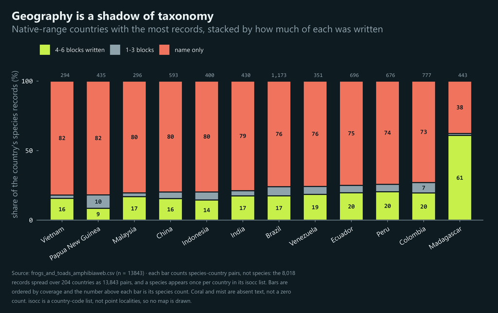

图 3: Country coverage follows taxonomic composition rather than national effort: the best-covered bar is a one-family island.

raw 8018 -> plotted 13843 (31 个物种没有 isocc；一个物种按 isocc 列表在每个国家各计一次，故记为「物种-国家」对而非物种数)

**读数**：7,987 个有 `isocc` 的物种摊到 204 个国家，共 13,843 个「物种—国家」对。入图的 12 个国家里，Madagascar（443 个物种记录）覆盖率 62% 最高，Vietnam（294 个）最低，18%。

但这根梯度不是「各国努力程度」的梯度，而是科构成的梯度。**国家的覆盖率是科构成的影子**：同一批国家换个科组成，覆盖率就会跟着换。

Madagascar 那一端是 Mantellidae——443 条记录里 297 条属于这个科。而这个科全表只有 300 个物种，其中 296 个只记在这一个国家，写过 63%。

Vietnam 那一端则主要由 Rhacophoridae（88 条，12% 写过）与 Megophryidae（68 条，16% 写过）组成——两个物种数不少、正文很少的科。

这张图不能说的：不能读成「某国资料更全」。`isocc` 只是范围代码，没有产地坐标、没有记录数、没有调查强度，物种数多不等于野外多。

表 4: 图 3 的原始数字（按覆盖率降序；「物种记录数」= 该国的物种—国家对数）

| 国家 | ISO | 物种记录数 | 4-6 块 | 1-3 块 | 只有名字 | 覆盖率 |
| --- | --- | --- | --- | --- | --- | --- |
| Madagascar | MG | 443 | 270 | 6 | 167 | 62.3% |
| Colombia | CO | 777 | 152 | 58 | 567 | 27.0% |
| Peru | PE | 676 | 138 | 36 | 502 | 25.7% |
| Ecuador | EC | 696 | 137 | 37 | 522 | 25.0% |
| Venezuela | VE | 351 | 65 | 20 | 266 | 24.2% |
| Brazil | BR | 1173 | 205 | 77 | 891 | 24.0% |
| India | IN | 430 | 75 | 16 | 339 | 21.2% |
| Indonesia | ID | 400 | 58 | 23 | 319 | 20.2% |
| China | CN | 593 | 92 | 28 | 473 | 20.2% |
| Malaysia | MY | 296 | 50 | 8 | 238 | 19.6% |
| Papua New Guinea | PG | 435 | 37 | 42 | 356 | 18.2% |
| Vietnam | VN | 294 | 46 | 7 | 241 | 18.0% |

## 五、是谁写的，以及这份档案的年龄

表 5: 署名最多的 8 位（submittedby）：一个名字基本等于一个科

| 署名者 | 条目数 | 占已署名条目 | 主笔的科 |
| --- | --- | --- | --- |
| Arne Schiøtz | 219 | 11.6% | Hyperoliidae (171, 78%) |
| Miguel Vences and Frank Glaw | 202 | 10.7% | Mantellidae (145, 72%) |
| Jean-Marc Hero et. al. | 197 | 10.5% | Myobatrachidae (110, 56%) |
| Raul E. Diaz | 109 | 5.8% | Centrolenidae (29, 27%) |
| Kellie Whittaker | 38 | 2.0% | Bufonidae (6, 16%) |
| Ansel Fong G. | 31 | 1.6% | Eleutherodactylidae (28, 90%) |
| Stephanie Ung | 31 | 1.6% | Microhylidae (10, 32%) |
| Marc-Oliver Rödel | 30 | 1.6% | Ptychadenidae (13, 43%) |

**笔是分科的。** 1,885 行有 `submittedby`，而且全部落在写过正文的条目里——有署名却空白的条目 0 行。署名与写作在这份数据里是同一件事。

455 个署名里，前 3 位写了 618 条，占已署名的 32.8%；前 10 位占 48.3%。

这解释了第二、三节的两头：Hyperoliidae 覆盖率 86% 不是因为它被格外重视，而是因为有一位作者整科写过它；Strabomantidae 的 10% 也不是没人管，而是没有人整科接手。这是**分工与相关**的陈述，不是因果推断：数据里没有任何一列写着「为什么」。

表 6: 这份档案自己的时间线（注意：两个日期都为空的那批条目，几乎就是空白条目）

| 项 | 值 |
| --- | --- |
| submit_date 最早 / 最晚 | 1999-02-16 / 2021-01-29 |
| submit_date 为空 | 6,117 行（76.3%） |
| edit_date 最早 / 最晚 | 2001-02-12 / 2026-09-27 |
| edit_date 为空 | 5,659 行（70.6%） |
| 两个日期都有 | 1,850 行 |
| 两个日期都没有 | 5,608 行（69.9%） |
| 两者都有时的中位滞后 | 7.6 年（n = 1,850） |
| 被编辑次数最多的三个人 | Kellie Whittaker 588 / Ann T. Chang 464 / Michelle S. Koo 210 |

**档案的年龄不是一条平滑的线。** 条目最后一次被编辑的时间跨 2001–2026。

可两个日期都没有的是 5,608 行（69.9%），而这批行几乎就是空白条目本身：5,650 行空白条目里只有 42 行留下过日期。

所以「记录深度」与「有没有日期」几乎是同一个变量。**不能**把编辑年份当成独立的时间轴去做趋势——那会变成只对 29.5% 的样本做时间分析。

对 1,850 个两个日期都有的条目，从提交到最近一次编辑的中位滞后是 7.6 年——这批条目在档案里躺了很久才被补写。`submit_date` 到 2021 只剩 2 条，之后的新条目基本只留编辑日期；这是录入口径的变化，不是收录的停止。

## 数据异常（记录，不改数据）

| 现象 | 原始数字 | 处理 |
| --- | --- | --- |
| IUCN 状态列全空 | `interntnl_status` 8,018 行、0 个非空（该列因此被读成 logical） | 不填补、不拿 `national_status` / `regional_status` 冒充；官方问题第三条明确写成「本快照无此数据」 |
| 国家级 / 地区级状态是自由文本 | `national_status` 209 行、`regional_status` 176 行，取值含 `None` / `N/A` / `Unknown` / `California` / `CALIFORNIA` | 不做任何评级汇总；大小写不一致说明是手工录入 |
| `refs` 大部分是占位符 | 2,076 个非空里 1,603 个去掉 `<p>` 后没有任何内容，真正含链接或 DOI 的只有 473 个 | 不计入记录分级；正文不用 `refs` 判断「被研究过」 |
| 散文字段是 HTML 片段 | `description` 非空行里 90% 含 `<i>` / `<p>` 等标签 | 只算长度与是否为空，不解析、不截断入表；也不剥离（剥离会改变原文） |
| `clade` 不是一个「支系」列 | 808 个非空，取值只有 57 种，其中 17 个是表内的**属名**，其余是亚科名，混了分类阶元 | 全页不使用；分类一律用 `family` / `subfamily` / `genus` |
| `intro_isocc`（引入地）格式残留 | 66 个非空里 41 个以逗号开头（如 `",BR"`） | 不参与入图；只记下「分布码拼接」这一事实 |
| `isocc` 有 31 个物种为空 | 31 行 | 图 3 的 n 用「物种—国家」对并写明差额；不把它们当「零分布」 |
| `lannoo` 是巨型转移文本 | 只有 96 行，中位长度 15,120 字符（最长 60,805） | 完全不进表、不进字长统计，否则整表被这 96 行撑爆 |
| `amphib_id` 有缺口 | 跨度 10,215，实有 8,018 行，缺 2,197 | 不用 id 推算物种数（缺口含别的目与已撤记录） |
| 空白条目几乎都没日期 | 两个日期都空 5,608 行；5,650 行空白条目里只有 42 行留下过日期 | 正文明确「时间维度只覆盖有日期的子集」；不把空日期读成「很久以前」，也不把这 42 行当成有时间信息的条目 |
| `submittedby` 是自由文本 | 含 “et. al.”、机构式合并（`Miguel Vences and Frank Glaw`）、重音字符（`Schiøtz`） | 按原文精确匹配计数，不做人名归并、不做音译 |

## 方法与口径

| 项 | 值 |
| --- | --- |
| 数据 | `data/frogs_and_toads_amphibiaweb.csv`（8,018 × 26，`amphib_id` 唯一，全部 `ordr == "Anura"`） |
| 覆盖 | 57 个科 / 504 个属 / 204 个 `isocc` 国家码 / 455 个 `submittedby` 署名 |
| 入图样本 | 图 1：raw 8018 -> plotted 8018 (全表入图，无剔除)；图 2：raw 8018 -> plotted 369 (135 个属不在入图的 14 个科里)；图 3：raw 8018 -> plotted 13843 (31 个物种没有 isocc；一个物种按 isocc 列表在每个国家各计一次，故记为「物种-国家」对而非物种数) |
| 「有正文」的定义 | 六个散文式字段（`description` / `distribution` / `life_history` / `larva` / `trends_and_threats` / `comments`）中至少一个非空；`refs` 与 `relation_to_humans` 不计入（前者多为占位符，后者只有 308 行） |
| 记录分级 | `full` = 6 个字段里 4–6 个非空（1,788 行）· `partial` = 1–3 个（580 行）· `none` = 0 个（5,650 行） |
| 图 1 口径 | 按 `family` 聚合，取物种数最多的 14 个科（占 79.1%）；左右共用一根线性轴，左为「只有名字」、右为「有正文」；标签是原始行数 |
| 图 2 口径 | 按「科 × 属」聚合，只取图 1 那 14 个科内的 369 个属；纵轴是同一批科，横轴是该属里有正文的物种占比；点面积 ∝ 属内物种数；点在行内抖动，重叠表示密集而非缺漏 |
| 图 3 口径 | 把 `isocc` 按逗号拆开，一个物种按其列表在每个国家各计一次（13,843 对）；取物种记录最多的 12 个国家，按覆盖率排序；每根条是 100% 堆叠的三级记录分级 |
| 不作为证据的列 | `interntnl_status`（全空）、`clade`（阶元混杂）、`national_status` / `regional_status`（自由文本）、`lannoo`（96 行巨型文本）、`refs`（77% 是占位符）；这些列都不能用来判断「某个类群被研究了多少」 |
| 不画的东西 | 不画世界地图（`isocc` 是国家码列表，没有坐标，画地图会把「档案覆盖」误读成「分布密度」）；不画编辑年份趋势（空白条目几乎全无日期，任何时间轴都只覆盖 29.5% 的样本）；不做 IUCN 分析（0 行可用）；不按国家排名下结论（国家覆盖差异主要是科构成差异，见第四节） |
| 数字来源 | 正文所有数字来自本页 prep chunk 的同一份聚合；内联数字一律经 `sprintf` / `format` 定型，避开 knitr 对大数的科学计数法改写 |